# Minimax

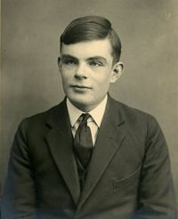

Alan Mathison Turing, Paddington, Londres, 23 de junio de 1912-Wilmslow, Cheshire, 7 de junio de 1954, fue un matemático, lógico, informático teórico, criptógrafo, filósofo, biólogo teórico, maratoniano y corredor de ultra distancia británico

En 1936 publicó el artículo “Sobre números computables, con una aplicación al Entscheidungsproblem” traducible como “problema de decisión”, que resultó ser el origen de la informática teórica.

En él definía qué era computable y qué no lo era. Lo computable era todo aquello que podía resolverse con un algoritmo conjunto de instrucciones finito que, mediante pasos sucesivos, lleva a la solución de un problema.

# Algoritmo Minimax-Alpha-Beta

# Algoritmo Minimax

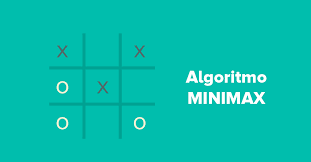

El algoritmo de búsqueda Minimax, es una búsqueda de profundidad limitada

El nombre del algoritmo se da al considerar que dada una función estática que devuelve valores en relación al jugador maximizante, este trata de maximizar su valor mientras que el oponente trata de minimizarlo

Funcionamiento

El funcionamiento de Minimax se define a como se puede elegir el mejor movimiento, dado el caso que el contrincante escoja el peor movimiento.

Realizar el algoritmo de Minimax se realiza en juegos sencillos, ya que implementarlo completamente consumiría gran cantidad de tiempo y memoria.

Teoría de Juegos

Su funcionamiento de Minimax es como se puede el mejor movimiento dado el caso que el contrincante realiza su peor movimiento.

También se realiza la búsqueda de árbol de las posibilidades y por lo cual podemos determinar un valor mediante la búsqueda heurística con fin de optimizar por nivel de profundidad o por otra forma como es el de ejecución.

Características

• El algoritmo nos ayuda a las personas con su respectivo nivel escalas.

• El algoritmo de Minimax nos ayuda a procedimientos recursivos.

• Gana un jugador.

• Nos permite explorar diferentes capas.

Pasos Minimax

1. Primero se debe generar todo el nodo y por lo cual uno meta para que se la llegada.
1. Calcular para cada nodo meta.
1. Se realiza el respectivo cálculo de los nodos superiores hacia los nodos inferiores donde el fin de conseguir valores mininos y máximos.
1. Se debe tomar en cuenta los valores del nivel superior.

Funcionalidades Minimax

1. Se debe contar con una posición inicial.
1. El conjunto de operación debe ser movidas.
1. Debemos tener en cuenta un nodo meta.
1. Funcionalidades gana, empate y pierda.

# Alpha-Beta

Alpha-Beta nos permite optimizar y reducir los tiempos de cálculo por lo siendo más rápido e ir a niveles de profundidad en un mayor en el árbol del juego

• Alfa: la mejor opción (de mayor valor) que hemos encontrado hasta ahora en cualquier punto del camino de Maximizer. El valor inicial de alfa es -∞ .

• Beta: la mejor opción (valor más bajo) que hemos encontrado hasta ahora en cualquier punto del camino de Minimizer. El valor inicial de beta es + ∞ .

Un factor sumamente importante es que depende el orden donde deben ser los visitantes los sucesores y por lo cual deben ser los mejores

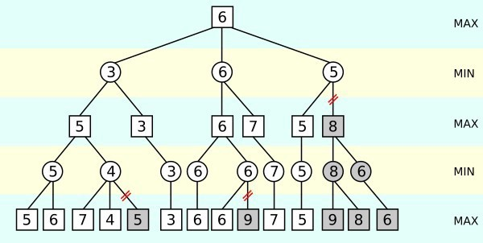

Desarrollo de esta técnica en el algoritmo

• Realizamos una búsqueda profunda para poder minimizar por lo cual se debe tener en cuenta los nodos al transcurso del camino.

• Los parámetros son muy esenciales para elegir el Max con el valor mas alto.

• Los parámetros son muy esenciales para elegir el min con el valor mas bajo.

# Explicar mediante un ejemplo práctico el funcionamiento del algoritmo

Supongamos que una empresa quiere realizar una campaña publicitaria.

Se le presentan 3 posibilidades:

• Radio 15 minutos de lunes ajueves en un espacio.

• TV 1 spot cada semana sobre las 12h

• Prensa 1 anuncio 2 días a la semana los lunes y los jueves

Como han hecho campañas anteriormente se han podido valorar los beneficios de las diferentes posibilidades del siguiente modo

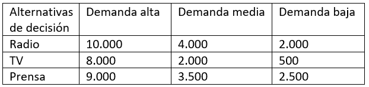

Optimista MaxiMax

Es cando unas de las alternativas de la matriz decisión como son las filas le escogemos el mayor valor y por lo cual al final se escoge también el más alto de todos

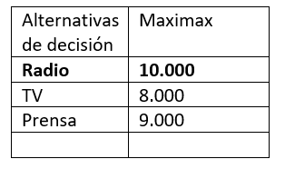

Es cando unas de las alternativas de la matriz decisión como son las filas le escogemos el menor valor y por lo cual al final se escoge también el más alto de todos

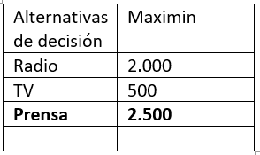

Tomando en cuenta una actitud positiva, el medio más adecuado para realizar la campaña publicitaria sería la radio. En el caso de los pesimistas, la prensa sería el medio más seguro

# Realizar una propuesta de como emplear el algoritmo en un problema del laberinto

Laberinto de conexión simple (LCS)

Son puntos muertos o callejones sin salida, por lo tanto, solo tienen una solución entre la entrada y la salida, en el proceso de buscar tal solución, en ocasiones, se recorre gran parte del laberinto.

[figure not shown]

Los laberintos son muy eficaz para buscar un solución y por lo cual primero analizar el laberinto antes de comenzar la partida y poder resolver en un menor tiempo con los demás competidores.

# Revisar al menos 4 papers científico de aplicaciones

1. Bernardo Hubert Ovalle Correa

   • La teoría fundamentada como método de investigación cualitativa para explicar la ausencia del estado en los diferentes niveles de emprendimientos

2.Revista Científica Mundo de la Investigación y el Conocimiento.

```
•The theory based on qualitative research method to explain the absence of the state at different levels of entrepreneurship
```

   • Un paseo por la historia de la Teorıa de Juegos
1. Antón Luisovich Rivero Rivero. Tutor: Dr. Uvedel Bernabé Del Pino Paz.

   • Uso de la Teoría de Juegos al proceso enseñanza – aprendizaje para lograr una mejor comprensión de los conceptos de la teoría de probabilidades

```python
#importamos las librerias
import os
import pygame
import sys
import time
import math
import random
```

```
pygame 1.9.6
Hello from the pygame community. https://www.pygame.org/contribute.html
```

```python
pygame.init()


win = pygame.display.set_mode((750, 500))

pygame.display.set_caption('Inteligencia Artificial Pong')

# Colores

white = (255, 255, 255)
black = (0, 0, 0)

# Clases Sprint

class Paddle1(pygame.sprite.Sprite):
    def __init__(self):
        pygame.sprite.Sprite.__init__(self)
        self.image = pygame.Surface([10, 75])
        self.image.fill(white)
        self.rect = self.image.get_rect()
        self.points = 0

class Paddle2(pygame.sprite.Sprite):
    def __init__(self):
        pygame.sprite.Sprite.__init__(self)
        self.image = pygame.Surface([10, 75])
        self.image.fill(white)
        self.rect = self.image.get_rect()
        self.points = 0

class Ball(pygame.sprite.Sprite):
    def __init__(self):
        pygame.sprite.Sprite.__init__(self)
        self.image = pygame.Surface([10, 10])
        self.image.fill(white)
        self.rect = self.image.get_rect()
        self.speed = 10
        self.dx = 1
        self.dy = 1

#Creacion

paddle1 = Paddle1()
paddle1.rect.x = 25
paddle1.rect.y = 225

paddle2 = Paddle2()
paddle2.rect.x = 715
paddle2.rect.y = 225

paddle_speed = 10

pong = Ball()
pong.rect.x = 375
pong.rect.y = 250


all_sprites = pygame.sprite.Group()
all_sprites.add(paddle1, paddle2, pong)
```

```python
# Funciones Pong
def redraw():
    win.fill(black)

    #Titulo
    font = pygame.font.SysFont('Comic Sans MS', 30)
    text = font.render('Inteligencia Artificial Pong', False, white)
    textRect = text.get_rect()
    textRect.center = (750 // 2, 25)
    win.blit(text, textRect)

    # Jugador 1
    p1_score = font.render(str(paddle1.points), False, white)
    p1Rect = p1_score.get_rect()
    p1Rect.center = (50, 50)
    win.blit(p1_score, p1Rect)

    # jugador 2
    p2_score = font.render(str(paddle2.points), False, white)
    p2Rect = p2_score.get_rect()
    p2Rect.center = (700, 50)
    win.blit(p2_score, p2Rect)

    all_sprites.draw(win)

    # Draws updates
    pygame.display.update()

run = True
```

```python
# Main
while run:

    pygame.time.delay(100)

    # Eventos
    for event in pygame.event.get():
        if event.type == pygame.QUIT:
            run = False

    # Movimientos con las teclas
    key = pygame.key.get_pressed()
    if key[pygame.K_w]:
        paddle1.rect.y += -paddle_speed
    if key[pygame.K_s]:
        paddle1.rect.y += paddle_speed
    if key[pygame.K_UP]:
        paddle2.rect.y += -paddle_speed
    if key[pygame.K_DOWN]:
        paddle2.rect.y += paddle_speed

    pong.rect.x += pong.speed * pong.dx
    pong.rect.y += pong.speed * pong.dy

    if pong.rect.y > 490:
        pong.dy = -1

    if pong.rect.y < 1:
        pong.dy = 1

    if pong.rect.x > 740:
        pong.rect.x, pong.rect.y = 375, 250
        pong.dx = -1
        paddle1.points += 1

    if pong.rect.x < 1:
        pong.rect.x, pong.rect.y = 375, 250
        pong.dx = 1
        paddle2.points += 1

    if paddle1.rect.colliderect(pong.rect):
        pong.dx = 1

    if paddle2.rect.colliderect(pong.rect):
        pong.dx = -1

    redraw()

pygame.quit()
```

[figure not shown]

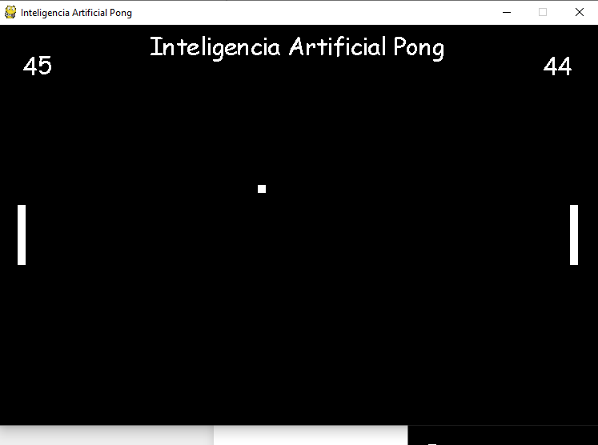

```python
#Realiado por Christian Hernandez
```